# Question

los Juegos Olímpicos se realizan cada cuatro años con la participación de países de mundial, alternando las sedes deportivas. La tabla muestra algunos datos de las últimas cinco versiones de los Juegos Olímpicos:

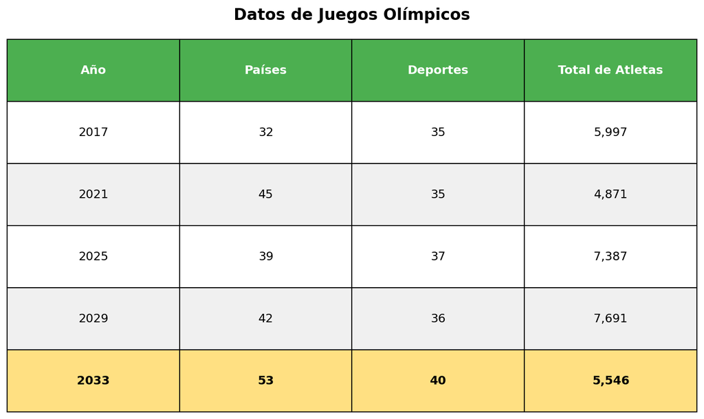

Del total de atletas participantes en 2033, el 5% compite en remo. Para determinar el número de atletas de remo ese año, se sugiere multiplicar 0.5 por el número de atletas que participaron en 2033. El procedimiento sugerido es:

## Answerlist

- incorrecto, porque se debe multiplicar 0.05 por el número de atletas participantes
- suficiente, porque el 5% representa la proporción exacta de atletas en remo
- insuficiente, porque se debe dividir entre el número de deportes practicados en 2033
- incorrecto, pues se debe multiplicar 0.05 por el número de atletas participantes

# Solution

Para resolver este problema, necesitamos evaluar si el procedimiento propuesto para calcular el número de atletas que compiten en remo es matemáticamente correcto.

### Análisis del procedimiento propuesto

**Datos disponibles:**

- Total de atletas en 2033: 5.546
- Porcentaje que compite en remo: 5%
- Procedimiento sugerido: multiplicar 0.5 por 5.546

### Identificación del error en el procedimiento

**Error en el procedimiento sugerido:**

El procedimiento propone multiplicar 0.5 por el total de atletas, pero esto es **INCORRECTO**.

**Procedimiento correcto:**

El cálculo de un porcentaje de una cantidad total se realiza multiplicando el porcentaje (expresado como decimal) por la cantidad total:

- 5% = 0.05 (no 0.5)
- **Cálculo correcto:** 5% de 5.546 = 0.05 × 5.546 = 277

**Cálculo con el procedimiento incorrecto sugerido:** 0.5 × 5.546 = 2.773 (esto sería el 50%, no el 5%)

### Evaluación de cada opción

**Análisis de la respuesta correcta:**

La respuesta correcta identifica que el procedimiento es **incorrecto** porque:

1. El valor 0.5 corresponde al 50%, no al 5%
2. Para calcular el 5% se debe usar 0.05, no 0.5
3. El error es confundir la representación decimal del porcentaje

### Conclusión

El procedimiento sugerido es **incorrecto** porque usa 0.5 en lugar de 0.05. La respuesta correcta identifica este error y proporciona el valor decimal correcto que debe usarse.

# Meta-information

exname: juegos_deportivos_interpretacion_representacion extype: schoice exsolution: 1000 exshuffle: TRUE exsection: Estadística|Análisis de datos|Porcentajes|Interpretación de tablas exextra[Type]: Interpretación y representación exextra[Level]: 2 exextra[Language]: es exextra[Course]: Matemáticas ICFES